# Applied Machine Learning

Torben Skov Dyg Johansen

tsdj@sam.sdu.dk & tsdj@rooftop-analytics.com

https://torbensdjohansen.github.io/

## Transformers: Translation To General-Purpose

**Note**: Numbers in square brackets indicate a reference (see list at end of slides), e.g., [1]

## About Me

- Master's of Economics from SDU
  - Bachelor thesis: ML for wind power curve estimation
  - Master's thesis: Combined with PhD (4+4) - some ML papers, some econ
- PhD-candidate at SDU in *Econometrics and Data Science* (Dept. of Econ.)
  - Created and taught AML back in '20
  - Research stay at Stanford University academic fall '22
- Data Scientist at Rooftop Analytics

## Working at Rooftop

Currently employed full-time as Data Scientist at Rooftop Analytics

We are an AI consulting firm that helps firms develop and deploy AI solutions for their business needs

This spans broadly - we work with firms within finance, energy, media, and more

## Recommender Systems

What we see online is largely determined by *recommender systems*

- What we see on our Facebook/SoMe feed
- What shows up on Google

When reading news, we care about different topics: I might not care for football news while wanting to stay on top of handball news

Good recommender systems help us achieve *personalization* that shows people what *they* care for

## Personalization at JFM

[figure not shown]

## Electricity Grid

Danish electrical grid is under extreme pressure due to increased electrification

- [Norlys](https://norlys.dk) plans to [invest 20 billion DKK in the years up to 2030](https://finans.dk/erhverv/ECE15656500/norlys-milliarder-skal-foerst-og-fremmest-geninvesteres/)
- Same pattern for other Danish firms
- ... and in other countries (e.g., Netherlands)

**Issue**: Complex problem deciding how and when to replace transformers - deterioration depends on multiple factors

- Consumption
- Capacity
  - Temperature
  - Placement
- Grid "level" (low vs. high voltage)
- Load balancing

## Danish High Voltage Grid ([Capacity Map](https://www.energy-supply.dk/article/view/783784/nyt_danmarkskort_guider_til_gode_steder_for_tilslutning_af_solceller_og_vindmoller))

[figure not shown]

## Link-Lives

To study issues such as social mobility, we need to be able to track individuals back multiple generations

While Danish register data is excellent, it does not allow us to go back very far (CPR: 1968, earlier/later depending on purpose)

**Link-Lives**: The ambitious project aiming at extending Danish register data back to 1787

**Problem**: Data volume is **large** and **handwritten**

[figure not shown]

## Link-Lives

**Aim**: Transcribe historical records and link individuals and families over time

[figure not shown]

## Your Experience with Transformers

Imagine if a single neural network architecture could solve all these - and many other - problems

[figure not shown]

## Preliminaries (1): Recurrent Neural Networks

We'll start by getting a bit ahead of ourselves. Consider a neural network the input of which is a sequence of related information (e.g., sentence, audio, time-series)

[figure not shown]

*One small problem: Actually not possible*

## Solution: Unroll it back to a non-recurrent network

[figure not shown]

Now we have a normal feedforward NN, with the exception of *parameter sharing*

## Preliminaries (2): Attention [1]

*Transformers* use a mechanism known as *attention*

This controls which part(s) of the network's inputs it should focus on ("pay *attention* to")

Why does this matter? Ofen not a one-to-one mapping between input and output

**Examples**:

1. Translation from one language to another (word order)
2. Summarization (content order)
3. Script generation (idea order)

## Translation Example

(Sorry to non-Danes) When translating the following sentence from Danish to English, which word(s) should we focus on?

**Danish**: "*Siden sidst har I [...]*"

**English (incomplete)**: "*Since last __ [...]*"

## Translation Example

(Sorry to non-Danes) When translating the following sentence from Danish to English, which word(s) should we focus on?

**Danish**: "*Siden sidst har I [...]*"

**English (incomplete)**: "*Since last time __ [...]*"

### English-to-french translation [1]

[figure not shown]

## What is a Transformer? [2]

Take a NN. Remove everything but *attention*. You now have a transformer (*possibly slightly oversimplified*)

*Query-key-value* approach: $\texttt{Attention}(Q, K, V) = \texttt{softmax}(\frac{QK^T}{\sqrt{d_k}})V$

```python
import math, torch

def attention(query, key, value) -> torch.Tensor:
    d_k = query.size(-1)
    scores = torch.matmul(query, key.transpose(-2, -1)) / math.sqrt(d_k)
    p_attn = scores.softmax(dim=-1)

    return torch.matmul(p_attn, value)
```

```python
query, key, value = torch.rand(2, 3), torch.rand(2, 3), torch.rand(2, 3)

attention(query, key, value)
```

```
tensor([[0.4835, 0.0610, 0.6033],
        [0.4512, 0.0591, 0.6368]])
```

## The Transformer: Multi-Head Attention [2]

[figure not shown]

## The Transformer: Architecture [2]

[figure not shown]

## The Transformer: Self-Attention [2]

[figure not shown]

## How to Train a Transformer

Transformers benefit *tremendously* from scale and large datasets

SOTA performance generally follows the pattern (1) pre-train on a large dataset and then (2) fine-tune on the desired task

**Question**: How do we (pre)-train a transformer? Specifically, which objective to optimize?

**Note**: We ultimately want versatile models: They should be able to translate, proof-read, help us code, summarize, etc.

**Idea**: Next-word prediction, e.g., "*The cat sat on the __*" ← now fill in the next word

**Limitaton**: Network only attends to previous words

- Useful for generative models (write me a program to do ...)
- Potentially harmful for word-level tasks such as Q&A, where context from the *right* might also be crucial

## BERT: Bidirectional Encoder Representations from Transformers [3]

**Idea**: Train transformers on Cloze tests

*[Cloze test](https://en.wikipedia.org/wiki/Cloze_test)*: Context and vocabulary test described by Wilson L. Taylor in 1953

**How many are familiar with the Cloze test**?

## BERT: Training [3]

**Cloze test**: "*The __ sat on the mat*" now fill in the **<BLANK>** (*this is slightly simplified*)

**Result**: Able to pre-train transformers that can attend to everything, not just to previous elements

**What was wild about BERT?**: It achieved SOTA on 11 benchmarks within NLP with a **unified architecture across tasks**

*Note*: This is not always optimal. For example, limited use for generative tasks

## BERT: Q&A [3]

[figure not shown]

## GPT-3 [4]

The GPT-3 paper from OpenAI is very interesting in its simplicity. They take a transformer and show that we don't need anything aside from (1) an auto-regressive model ("*predict next word*") and (2) scale to achieve SOTA

There is a tremendous engineering feat in being able to scale up as much as they do (175B params), but the gist of training is relatively simple

## GPT-3 Training (sketch)

```python
import torch

model = torch.nn.Transformer() # with some diff param values
dataset = torch.utils.data.DataLoader(TextParagraphs()) # hypothetical dataset

optimizer = torch.optim.Adam(model) # with some gradient clipping, weight decay
scheduler = torch.optim.lr_scheduler.CosineAnnealingLR(optimizer) # they also use linear warmup

loss_fn = torch.nn.CrossEntropyLoss(ignore_index=PAD_IDX)

for sentences, sentences_shifted in dataset: # 2048 tokens long
    optimizer.zero_grad()

    output = model(sentences) # also some target and masking provided
    loss = loss_fn(yhat, sentences_shifted)

    loss.backward()

    optimizer.step() # they also scale the batch size
    scheduler.step()
```

## GPT-3: Performance Without Fine-Tuning [4]

Size leads to performance even without fine-tuning

[figure not shown]

## Visition Transformers (ViTs) [5]

Not entirely obvious that transformers would work for images - no longer a sequence

But what if we represented an image as a sequence?

[figure not shown]

## ViTs and CNNs [5]

ViTs impose fewer assumptions on the data compared to CNNs

- Inductive biases (translation equivariance and locality) are a strength and a weakness of CNNs

With large datasets, ViTs beat CNNs

Later papers have showed that large datasets are not needed for ViTs to beat CNNs

[figure not shown]

## ViT in Code

This will very much be a "*sketch*" - but it *is* close to the real thing

```python
import torch

class PatchEmbed(torch.nn.Module):
    def __init__(self, patch_size=(16, 16)):
        super().__init__()
        self.proj = nn.Conv2d(
            3, 768, kernel_size=patch_size, stride=patch_size)

    def forward(self, x):
        x = self.proj(x)
        x = x.flatten(2).transpose(1, 2)  # NCHW -> NLC

        return x
```

```python
patch_embed = PatchEmbed()

image = torch.rand(1, 3, 224, 224) # 3x224x224 Image
patch_embed(image).shape # Sequence with length 196
```

```
torch.Size([1, 196, 768])
```

```python
class Attention(torch.nn.Module):
    def __init__(self):
        super().__init__()

        self.head_dim = 768 // 8 # 8 heads
        self.scale = 8 ** -0.5 # this is d_k

        self.qkv = nn.Linear(768, 768 * 3)
        self.proj = nn.Linear(768, 768)

    def forward(self, x):
        B, N, C = x.shape

        q, k, v = self.qkv(x).reshape(B, N, 3, 8, self.head_dim).permute(2, 0, 3, 1, 4).unbind(0)
        q = q * self.scale

        attn = q @ k.transpose(-2, -1).softmax(dim=-1) # recall formula
        x = attn @ v

        x = x.transpose(1, 2).reshape(B, N, C)
        x = self.proj(x)

        return x
```

```python
attention = Attention()

attention(patch_embed(image)).shape
```

```
torch.Size([1, 196, 768])
```

```python
class VisionTransformer(torch.nn.Module):
    def __init__(self):
        super().__init__()
        self.patch_embed = PatchEmbed()
        self.attn = Attention()
        self.head = torch.nn.Linear(768, 3)

    def forward(self, x):
        x = self.patch_embed(x)
        # Here we would add some positional info
        x = x + self.attn(x)
        x = self.head(x.mean(dim=1))

        return x
```

```python
vit = VisionTransformer()

vit(image).shape
```

```
torch.Size([1, 3])
```

```python
vit(image).argmax(axis=1)
```

```
tensor([2])
```

## From Transformers to ChatGPT [6]

If GPT-3 is from 2020, how come it took until 2022 for ChatGPT to surface?

"*[...] large language models can generate outputs that are untruthful, toxic, or simply not helpful to the user. In other words, these models are **not aligned** with their users.*"

Then how do we align them?

## RL from Human Feedback [6]

[figure not shown]

## State of the Art, 2023

**How?** Large Transformers + RLHF

**More than text**: Handles images, coding, making slides, art, etc.

### OpenAI/GPT-4 [7]

Proprietary model - but SOTA performance

Available through OpenAI API - subscription costs

### Meta/Llama 2 [8]

Model freely available for use (incl. commercial) - but lacks behind OpenAI (as also clearly stated in the [Llama 2 paper](https://ai.meta.com/research/publications/llama-2-open-foundation-and-fine-tuned-chat-models/))

## GPT-4 vs. Llama 2 [8]

[figure not shown]

## Image-To-Text with Double Transformers

*Typical examples of names from the HANA database*

[figure not shown]

We can use ViTs for images and Transformers for text - we can also *combine the two* to create a network for image-to-text

## Image-To-Text with Double Transformers

```python
from timmsn.models.layers import TransformerDecoder

class ImageToTextTransformer(nn.Module):
    def __init__(self):
        super().__init__()
        self.encoder = VisionTransformer() # ViT
        self.decoder = TransformerDecoder(3, 768, 8, 30) # Transformer

    def encode(self, image): # encode image as sequence
        return self.encoder.forward_features(image)

    def decode(self, memory, target_mask, target_padding_mask):
        return self.decoder(memory, target, target_mask, target_padding_mask)

    def forward(self, image, target, target_mask, target_padding_mask):
        memory = self.encode(image)
        out = self.decode(memory, target, target_mask, target_padding_mask)

        return out
```

## Image-To-Text with Double Transformers

```python
from timm.models import load_checkpoint
from timmsn.models import create_model_v2

# Create our model
model = create_model_v2(
    feature_extractor_name='deit3_base_patch16_224_in21ft1k',
    num_classes=20*[34],
    global_pool='token',
    image_size=(3, 144, 940),
    classifier_name='seq2seq_mh_mix_mask25',
    )
load_checkpoint(model, 'Y:/X-to-Y/hana-model.tar') # load pre-trained
```

## Image-To-Text with Double Transformers

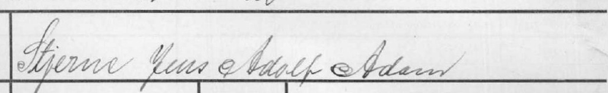

```python
from PIL import Image

# Load an image
image = Image.open('Y:/X-to-Y/example-image.jpg').convert("RGB")
image
```

## Image-To-Text with Double Transformers

```python
from timm.data.transforms_factory import create_transform
from timmsn.data.transforms import Resize
```

```python
pipeline = create_transform((144, 940))
pipeline.transforms.insert(0, Resize(144, 940))

image_procesed = pipeline(image).unsqueeze(0)

model.encode(image_procesed).shape # Sequence length 523

# For prediction we need to decode ARs
# Correctly outputs last name as "Stjerne"
# Correct in 96.8% of cases
```

```
torch.Size([1, 523, 768])
```

## Want to Explore the HANA Database?

You can find the HANA database [here](https://www.kaggle.com/datasets/sdusimonwittrock/hana-database)

Using $\texttt{timmsn}$ to replicate results

```
python -m torch.distributed.launch --nproc_per_node=2 train.py ^
--formatter lastword ^
--experiment EXPERIMENT-FOLDER-NAME ^
--output path/to/output/folder ^
--input-size 3 80 522 ^
--epochs 90 ^
--data_dir path/to/HANA/database ^
--dataset HANA ^
--config ./cfgs/deit3_b_s2s.yaml
```

```
python evaluate.py ^
--config path/to/output/folder/EXPERIMENT-FOLDER-NAME/args.yaml ^
--checkpoint path/to/output/folder/EXPERIMENT-FOLDER-NAME/last.pth.tar ^
--output path/to/eval/output
```

```
python evaluate.py ^
--config path/to/output/folder/EXPERIMENT-FOLDER-NAME/args.yaml ^
--checkpoint path/to/output/folder/EXPERIMENT-FOLDER-NAME/last.pth.tar ^
--output path/to/transcription/output ^
--predict-folders path/to/new/images
```

## Getting Started with Transformers

Interested? Cannot recommend [The Annotated Transformer](https://nlp.seas.harvard.edu/annotated-transformer/) enough - amazing introduction

Interested in the best part of ML images? Check out [PyTorch Image Models](https://github.com/huggingface/pytorch-image-models)

## Reach Out!

**Interested in learning more about Rooftop Analytics?** Check our website https://www.rooftop-analytics.com/

**Interested in learning more about me?** Check my website https://torbensdjohansen.github.io/

### References (w/ arXiv link where available)

[1] [Bahdanau, Dzmitry, Kyunghyun Cho, and Yoshua Bengio. "Neural machine translation by jointly learning to align and translate." arXiv preprint arXiv:1409.0473 (2014).](https://arxiv.org/pdf/1409.0473.pdf)

[2] [Vaswani, Ashish, et al. "Attention is all you need." Advances in neural information processing systems 30 (2017).](https://arxiv.org/pdf/1706.03762.pdf)

[3] [Devlin, Jacob, et al. "Bert: Pre-training of deep bidirectional transformers for language understanding." arXiv preprint arXiv:1810.04805 (2018).](https://arxiv.org/pdf/1810.04805.pdf)

[4] [Brown, Tom, et al. "Language models are few-shot learners." Advances in neural information processing systems 33 (2020): 1877-1901.](https://arxiv.org/pdf/2005.14165.pdf)

[5] [Dosovitskiy, Alexey, et al. "An image is worth 16x16 words: Transformers for image recognition at scale." arXiv preprint arXiv:2010.11929 (2020).](https://arxiv.org/pdf/2010.11929.pdf)

[6] [Ouyang, Long, et al. "Training language models to follow instructions with human feedback." Advances in Neural Information Processing Systems 35 (2022): 27730-27744.](https://arxiv.org/pdf/2203.02155.pdf)

[7] [OpenAI "GPT-4 Technical Report." (2023)](https://arxiv.org/pdf/2303.08774.pdf)

[8] [Touvron, Hugo, et al. "Llama 2: Open foundation and fine-tuned chat models." arXiv preprint arXiv:2307.09288 (2023).](https://ai.meta.com/research/publications/llama-2-open-foundation-and-fine-tuned-chat-models/)

## Additional Credits

Figure on slide **Personalization at JFM** taken from https://jfm.dk

Figure on slide **Link-Lives** taken from https://link-lives.dk/en/video-creating-historical-big-data-with-danish-sources/

Figure on the slide **Preliminaries (1): Recurrent Neural Networks** taken from Deep Learning with Python by Francois Collet (ISBN10: 9781617294433).

Figure on the slide **Solution: Unroll it back to a non-recurrent network** source: "fdeloche - Own work, CC BY-SA 4.0, https://commons.wikimedia.org/w/index.php?curid=60109157"